# seaborn风格设置和调色盘设置

```python
import numpy as np
import pandas as pd
import matplotlib.pyplot as plt
import seaborn as sns
```

# 1 seaborn风格设置

用seaborn绘图，比直接使用matplotlib绘图更加的美观。原因就是因为seaborn中已经将一些属性的样式进行了调整。我们可以直接使用，也可以修改他的样式。

## 1.1 seaborn预设设计风格

seaborn中自带了5种样式。分别是：

- white：纯白色的。
- whitegrid：带有网格的白色的。
- dark：灰色的。
- darkgrid：带有网格的灰色的（网格线是白色的），默认。
- ticks：白色的，并且在轴上带有刻度条的。

```python
# 导入tips数据集进行演示
tips = pd.read_csv("../data/tips.csv")
```

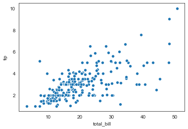

```python
# white样式
sns.set_style("white")
sns.scatterplot(x="total_bill",y="tip",data=tips)
```

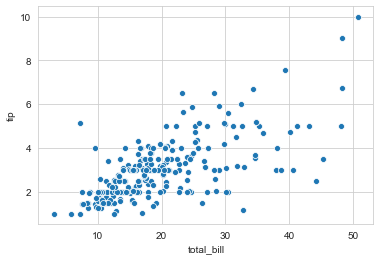

```python
# whitegrid样式
sns.set_style("whitegrid")
sns.scatterplot(x="total_bill",y="tip",data=tips)
```

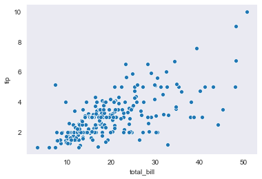

```python
# dark样式
sns.set_style("dark")
sns.scatterplot(x="total_bill",y="tip",data=tips)
```

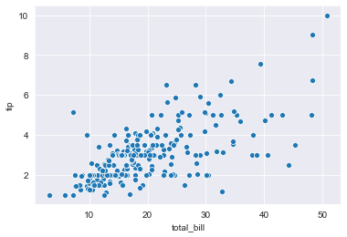

```python
# darkgrid样式
sns.set_style("darkgrid")
sns.scatterplot(x="total_bill",y="tip",data=tips)
```

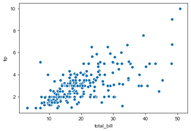

```python
# ticks样式
sns.set_style("ticks")
sns.scatterplot(x="total_bill",y="tip",data=tips)
```

## 1.2 去掉图形边线

在white和ticks主题中，我们并不需要上边和右边的边界。我们可以使用despine()来干掉他们：

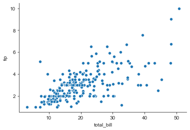

```python
# 绘制图像
sns.scatterplot(x="total_bill",y="tip",data=tips)

# 去掉上边和右边的边界
sns.despine()
```

- 我们也可以通过额外的参数来决定去除哪些边界：

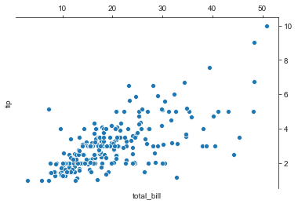

```python
# 绘制图像
sns.scatterplot(x="total_bill",y="tip",data=tips)

# 去掉左边和下边的边界
sns.despine(left=True,bottom=True,top=False,right=False)
```

## 1.3 临时修改设计风格

虽然我们可以很容易地改来改去，但有些情况下，我们使用with语句搭配axes_style()函数会更好。使用这种方法，我们可以在一张图的不同坐标轴中使用不同的设计

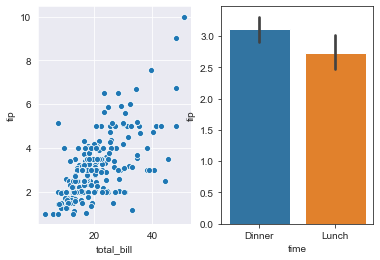

```python
# 创建一个画布
f = plt.figure()

# 使用with和sns.axes_style进行临时风格设定
with sns.axes_style("darkgrid"):
    # 添加子图1，并进行darkgrid风格的绘制图形
    ax = f.add_subplot(1, 2, 1)
    sns.scatterplot(x="total_bill",y="tip",data=tips)

# 添加子图2，并按照默认风格进行绘制图形
ax = f.add_subplot(1, 2, 2)
sns.barplot(x="time",y="tip",data=tips)
```

## 1.4 重载seaborn的设计元素

如果我们想定制seaborn的设计风格，我们还可以给axes_style()或者set_style()的rc参数传递一个字典，这个字典由各种各样的设置项组成。需要注意的是，我们只能重载那些已经被定义好的选项。（不过更高级的set()函数可以接受任何matplotlib参数组成的字典）。

如果我们想看它们支持哪些选项，我们可以不加任何参数地调用它们，这样它们就会返回当前的配置：

```python
# 显示当前seaborn的配置
sns.axes_style()
```

```
{'axes.facecolor': 'white',
 'axes.edgecolor': '.15',
 'axes.grid': False,
 'axes.axisbelow': True,
 'axes.labelcolor': '.15',
 'figure.facecolor': 'white',
 'grid.color': '.8',
 'grid.linestyle': '-',
 'text.color': '.15',
 'xtick.color': '.15',
 'ytick.color': '.15',
 'xtick.direction': 'out',
 'ytick.direction': 'out',
 'lines.solid_capstyle': 'round',
 'patch.edgecolor': 'w',
 'image.cmap': 'rocket',
 'font.family': ['sans-serif'],
 'font.sans-serif': ['Arial',
  'DejaVu Sans',
  'Liberation Sans',
  'Bitstream Vera Sans',
  'sans-serif'],
 'patch.force_edgecolor': True,
 'xtick.bottom': True,
 'xtick.top': False,
 'ytick.left': True,
 'ytick.right': False,
 'axes.spines.left': True,
 'axes.spines.bottom': True,
 'axes.spines.right': True,
 'axes.spines.top': True}
```

- 然后我们就可以进行修改和重载了：

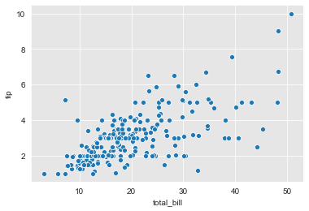

```python
# 修改seaborn风格，并绘制图形
sns.set_style("darkgrid", {"axes.facecolor": ".9"})
sns.scatterplot(x="total_bill",y="tip",data=tips)
```

## 1.5 缩放图形元素

有一系列单独的参数可以用于控制图形元素的缩放，这样我们就可以使用同样的代码来使得我们的图片可以适应不同的应用场景（有时可能需要更大的图片，但有时却刚好相反）。

首先我们先重置所有的设置：

```python
# 重置seaborn的设置
sns.set()
```

我们有四种预设的背景，按照相对大小来排序，分别是paper、notebook、talk和poster。上文的那些图片中使用的都是默认的notebook风格，下面展示4种风格。

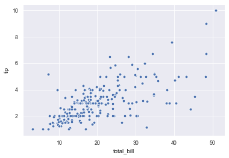

```python
# 设置paper风格
sns.set_context("paper")
sns.scatterplot(x="total_bill",y="tip",data=tips)
```

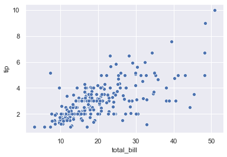

```python
# 设置notebook风格
sns.set_context("notebook")
sns.scatterplot(x="total_bill",y="tip",data=tips)
```

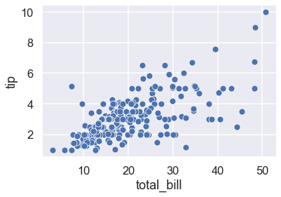

```python
# 设置talk风格
sns.set_context("talk")
sns.scatterplot(x="total_bill",y="tip",data=tips)
```

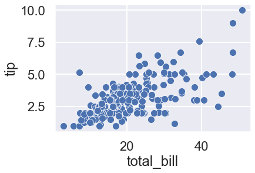

```python
# 设置poster风格
sns.set_context("poster")
sns.scatterplot(x="total_bill",y="tip",data=tips)
```

# 2 seaborn调色盘设置

seaborn可以非常迅速的做出优美的图形，其中就应该得力于他的调色盘机制。seaborn根据应用场景提供了三种不同类型的调色盘：定性的、连续的、发散的。

## 2.1 定性调色盘

定性调色盘。一般在数据不连续，比较离散，想体现分类的情况下使用。在seaborn中，使用sns.color_palette来创建调色盘。

### 2.1.1 默认调色盘

在seaborn中，默认情况下就设置了一些颜色供绘图使用。使用sns.color_palette即可获取。并且我们可以通过sns.palplot来绘制调色盘。示例代码如下：

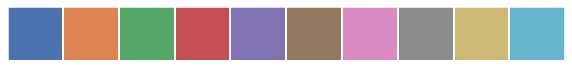

```python
# 获取当前的调色盘设置
current_palette = sns.color_palette()

# 绘制调色盘
sns.palplot(current_palette)
```

默认的调色盘有10种颜色。这些颜色都有6种风格。分别是：deep，muted，pastel， bright，dark，colorblind。这几种风格的颜色不变，主要调整的是亮度和饱和度。

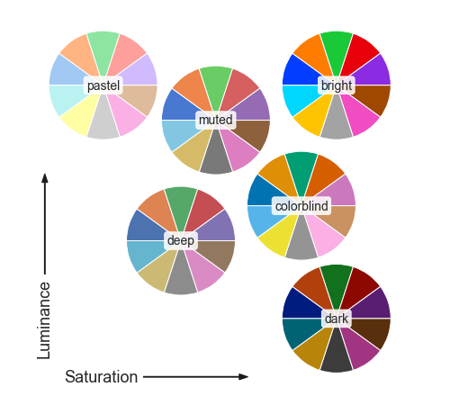

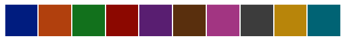

```python
# 设置调色盘的风格为dark
current_palette = sns.color_palette("dark")

# 绘制调色盘
sns.palplot(current_palette)
```

### 2.1.2 hls圆形颜色系统

hls圆形颜色系统是颜色按照顺序，经过偏移，无缝形成一个圆形。我们在使用这个调色盘的时候，可以指定需要使用多少种颜色。示例代码如下：

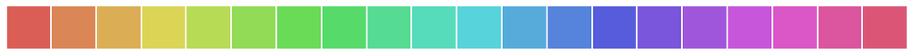

```python
# 使用hls圆形颜色系统，取20个颜色
sns.palplot(sns.color_palette("hls",20))
```

也可以使用另外一个函数sns.hls_palette(n_colors=6, h=0.01, l=0.6, s=0.65)来实现。这个函数可以传递更多的参数。

- h: 更改开始的颜色
- l: 调整亮度
- s: 调整饱和度

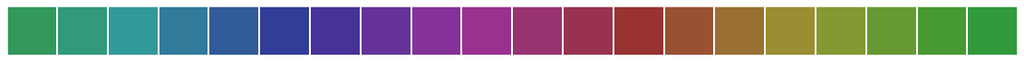

```python
# 通过调整h、l和s来调整开始的颜色，亮度和饱和度
sns.palplot(sns.hls_palette(20,h=0.4,l=0.4,s=0.5))
```

另外也可以通过sns.husl_palette来实现色系的调整，这个方法比sns.hls_palette亮度和饱和度更加的均匀。

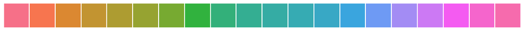

```python
# 使色系的亮度和饱和度更均匀
sns.palplot(sns.husl_palette(20))
```

### 2.1.3 分类颜色

分类颜色是seaborn已经提前给你定义了一些颜色，使用这些颜色在做分类分组的时候可以按照自己的需求选择。示例代码如下：

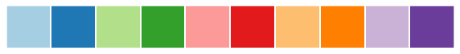

```python
# 显示5组颜色对
sns.palplot(sns.color_palette("Paired",10))
```

关于分类的颜色选择，可以通过sns.choose_colorbrewer_palette("qualitative")来查看。这个方法只能用在jupyter notebook中。可以选择不同的样式，然后还可以调节饱和度等。

```python
# 选择不同的样式
sns.choose_colorbrewer_palette("qualitative")
```

```
[(0.8941176470588235, 0.10196078431372557, 0.10980392156862737),
 (0.21568627450980393, 0.4941176470588236, 0.7215686274509804),
 (0.3019607843137256, 0.6862745098039216, 0.29019607843137263),
 (0.5960784313725492, 0.3058823529411765, 0.6392156862745098),
 (1.0, 0.4980392156862745, 0.0),
 (0.9999999999999998, 1.0, 0.19999999999999996),
 (0.6509803921568629, 0.33725490196078434, 0.1568627450980391),
 (0.9686274509803922, 0.5058823529411766, 0.7490196078431374),
 (0.6, 0.6, 0.6)]
```

### 2.1.4 用xkcd颜色

xkcd是一个漫画名称或者是工作室。xkcd开展了一项众包活动，为随机的RGB颜色命名。这产生了一组954种命名颜色。详细的颜色可以查看官网https://xkcd.com/color/rgb/ 一些示例如下：

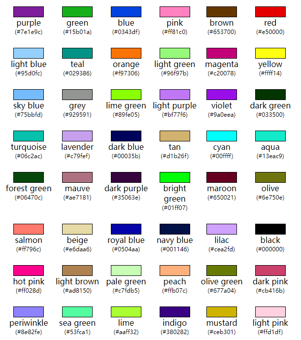

我们可以从sns.xkcd_palette里面提取颜色。提取到后，如果想要用在palette参数中，那么还需要放到sns.xkcd_palette中。

```python
# 获取名字为blue green的颜色
print(sns.xkcd_rgb["blue green"])

# 用xkcd的颜色名称构建一个palette对象
colors = ["windows blue", "amber", "greyish", "faded green", "dusty purple"]
sns.palplot(sns.xkcd_palette(colors))
```

[output not shown]

```
#137e6d
```

## 2.2 连续颜色盘

有时候我们绘图的时候，想要使用一个同种色系，但是不同深浅，这时候就可以使用连续的颜色盘。示例代码如下：

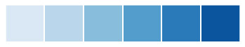

```python
# 绘制同一色系的颜色盘
sns.palplot(sns.color_palette("Blues"))
```

- 默认颜色是从浅入深，如果想要从深变浅，那么可以在色系后加一个_r。示例代码如下：

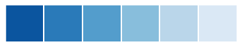

```python
# 由深到浅的颜色盘
sns.palplot(sns.color_palette("Blues_r"))
```

- 我们也可以通过sns.choose_colorbrewer_palette("sequential")查看有哪些色系可供选择。

```python
sns.choose_colorbrewer_palette("sequential")
```

```
[(0.9575547866205305, 0.9575547866205305, 0.9575547866205305),
 (0.9012072279892349, 0.9012072279892349, 0.9012072279892349),
 (0.8328950403690888, 0.8328950403690888, 0.8328950403690888),
 (0.7502191464821223, 0.7502191464821223, 0.7502191464821223),
 (0.6434140715109573, 0.6434140715109573, 0.6434140715109573),
 (0.5387158785082661, 0.5387158785082661, 0.5387158785082661),
 (0.440322952710496, 0.440322952710496, 0.440322952710496),
 (0.342883506343714, 0.342883506343714, 0.342883506343714),
 (0.22329873125720878, 0.22329873125720878, 0.22329873125720878),
 (0.10469819300269129, 0.10469819300269129, 0.10469819300269129)]
```

## 2.3 离散调色盘

离散的色盘，是两边的颜色逐渐加深，中间的颜色最淡。或者是中间的颜色最深，两边的颜色最淡。一般离散的色盘可以用于比如温度，零度以上可以用红色表示，零度以下用蓝色表示。越红的地方，表示温度越高，越蓝的地方，表示温度越低。示例代码如下：

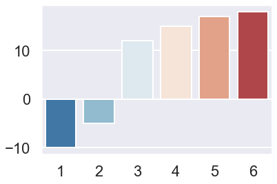

```python
# 构建一个温度数据
values = [12,15,17,18,-5,-10]

# 用离散调色盘来绘制条形图
with sns.color_palette("RdBu_r"):
    sns.barplot([1,2,3,4,5,6],sorted(values))
```

- 也可以通过sns.choose_colorbrewer_palette("diverging")查看离散的色盘有哪些可以选择。

```python
# 查看离散调色盘
sns.choose_colorbrewer_palette("diverging")
```

```
[(0.6922722029988467, 0.09227220299884642, 0.16770472895040373),
 (0.8392156862745099, 0.376470588235294, 0.3019607843137253),
 (0.9545559400230679, 0.641753171856978, 0.5057285659361783),
 (0.9921568627450982, 0.8588235294117645, 0.7803921568627449),
 (0.9657054978854286, 0.9672433679354094, 0.9680891964628989),
 (0.8196078431372551, 0.8980392156862745, 0.9411764705882353),
 (0.5664744329104192, 0.7687043444828916, 0.8685121107266438),
 (0.26274509803921564, 0.576470588235294, 0.7647058823529411),
 (0.1272587466359093, 0.39584775086505203, 0.6687427912341407)]
```

- 还可以通过sns.diverging_palette(h_neg, h_pos, s=75, l=50, sep=10, n=6, center='light', as_cmap=False)来自定义离散色盘。